# M03-2: Data Visualization-Application Assignment

Author

Allen Cosme

Published

March 2, 2026

```r
#install.packages("ggplot2")
#install.packages("gt")
library(tidyverse)
library(ggrepel)
library(ggthemes)
library(scales)
library(plotly)
library(lattice)
library(GGally)
```

```r
# install this package:
install.packages("wooldridge")
```

```
Error in `contrib.url()`:
! trying to use CRAN without setting a mirror
```

```r
library(wooldridge)
help(attend)
df <- attend
head(df)
```

```
  attend termGPA priGPA ACT final atndrte hwrte frosh soph missed     stndfnl
1     27    3.19   2.64  23    28  84.375 100.0     0    1      5  0.47268906
2     22    2.73   3.52  25    26  68.750  87.5     0    0     10  0.05252101
3     30    3.00   2.46  24    30  93.750  87.5     0    0      2  0.89285713
4     31    2.04   2.61  20    27  96.875 100.0     0    1      1  0.26260504
5     32    3.68   3.32  23    34 100.000 100.0     0    1      0  1.73319328
6     29    3.23   2.93  26    25  90.625 100.0     0    1      3 -0.15756303
```

```r
class(df)
```

```
[1] "data.frame"
```

```r
df <- as_tibble(df)
df
```

```
# A tibble: 680 × 11
   attend termGPA priGPA   ACT final atndrte hwrte frosh  soph missed stndfnl
    <int>   <dbl>  <dbl> <int> <int>   <dbl> <dbl> <int> <int>  <int>   <dbl>
 1     27    3.19   2.64    23    28    84.4 100       0     1      5  0.473
 2     22    2.73   3.52    25    26    68.8  87.5     0     0     10  0.0525
 3     30    3      2.46    24    30    93.8  87.5     0     0      2  0.893
 4     31    2.04   2.61    20    27    96.9 100       0     1      1  0.263
 5     32    3.68   3.32    23    34   100   100       0     1      0  1.73
 6     29    3.23   2.93    26    25    90.6 100       0     1      3 -0.158
 7     30    1.54   1.94    21    10    93.8  75       1     0      2 -3.31
 8     26    2      2.12    22    34    81.2 100       0     1      6  1.73
 9     24    2.25   2.06    24    26    75   100       1     0      8  0.0525
10     29    3      2.73    21    26    90.6 100       0     1      3  0.0525
# ℹ 670 more rows
```

Variable Definition - attend: classes attended out of 32 - termGPA: GPA for term - priGPA: cumulative GPA prior to term - ACT: ACT score - final: final exam score - atndrte: percent classes attended - hwrte: percent homework turned in - frosh: =1 if freshman - soph: =1 if sophomore - missed: number of classes missed - stndfnl: (final - mean)/sd

# 1 Ex 1: GT table

```r
# install.packages(c("wooldridge","gt","dplyr"))  # if needed
library(wooldridge)
library(dplyr)

library(gt)
data("attend")

# A clean, presentable summary table using gt
attend %>%
  select(attend, termGPA, priGPA, ACT, final, atndrte, hwrte, frosh, soph, missed, stndfnl) %>%
  summarise(
    across(
      everything(),
      list(
        N = ~sum(!is.na(.)),
        Mean = ~mean(., na.rm = TRUE),
        SD = ~sd(., na.rm = TRUE),
        Min = ~min(., na.rm = TRUE),
        Max = ~max(., na.rm = TRUE)
      )
    )
  ) %>%
  tidyr::pivot_longer(
    cols = everything(),
    names_to = c("Variable", ".value"),
    names_sep = "_"
  ) %>%
  gt() %>%
  tab_header(
    title = "Wooldridge Dataset: attend",
    subtitle = "Descriptive statistics for key variables"
  ) %>%
  cols_label(
    Variable = "Variable",
    N = "N",
    Mean = "Mean",
    SD = "Std Dev",
    Min = "Min",
    Max = "Max"
  ) %>%
  fmt_number(
    columns = c(Mean, SD, Min, Max),
    decimals = 2
  ) %>%
  tab_style(
    style = cell_text(weight = "bold"),
    locations = cells_column_labels(everything())
  ) %>%
  tab_options(
    table.font.size = px(14),
    heading.title.font.size = px(20),
    heading.subtitle.font.size = px(14),
    table.width = pct(90)
  ) %>%
  data_color(
    columns = Mean,
    method = "numeric",
    palette = c("#e8f5e9", "#66bb6a", "#1b5e20")
  ) %>%
  tab_source_note(
    source_note = "Source: wooldridge::attend"
  )
```

Wooldridge Dataset: attend

Descriptive statistics for key variables

| Variable | N | Mean | Std Dev | Min | Max |
| --- | --- | --- | --- | --- | --- |
| attend | 680 | 26.15 | 5.46 | 2.00 | 32.00 |
| termGPA | 680 | 2.60 | 0.74 | 0.00 | 4.00 |
| priGPA | 680 | 2.59 | 0.54 | 0.86 | 3.93 |
| ACT | 680 | 22.51 | 3.49 | 13.00 | 32.00 |
| final | 680 | 25.89 | 4.71 | 10.00 | 39.00 |
| atndrte | 680 | 81.71 | 17.05 | 6.25 | 100.00 |
| hwrte | 674 | 87.91 | 19.27 | 12.50 | 100.00 |
| frosh | 680 | 0.23 | 0.42 | 0.00 | 1.00 |
| soph | 680 | 0.58 | 0.49 | 0.00 | 1.00 |
| missed | 680 | 5.85 | 5.46 | 0.00 | 30.00 |
| stndfnl | 680 | 0.03 | 0.99 | −3.31 | 2.78 |

Source: wooldridge::attend

# 2 Ex2: Scatter plot with ggplot2

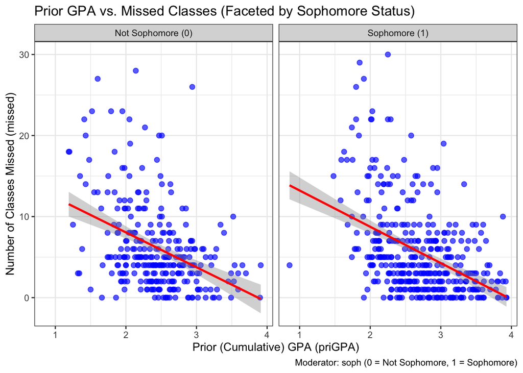

```r
# install.packages(c("wooldridge","ggplot2","dplyr"))  # if needed
library(wooldridge)
library(ggplot2)
library(dplyr)

data("attend")
df <- attend  # since your prompt says variables are inside df

# (Optional) Make soph readable for faceting/caption
df <- df %>%
  mutate(
    soph_f = factor(soph, levels = c(0, 1),
                    labels = c("Not Sophomore (0)", "Sophomore (1)"))
  )

# 2.1 + 2.2 + 2.3 (and a bit extra polish)
ggplot(df, aes(x = priGPA, y = missed)) +
  geom_point(size = 2, color = "blue", alpha = 0.65) +         # points: size=2, blue
  geom_smooth(method = "lm", se = TRUE, color = "red") +       # regression line: red
  facet_wrap(~ soph_f) +                                       # facet by soph
  theme_bw() +                                                 # theme bw
  labs(
    title = "Prior GPA vs. Missed Classes (Faceted by Sophomore Status)",
    x = "Prior (Cumulative) GPA (priGPA)",
    y = "Number of Classes Missed (missed)",
    caption = "Moderator: soph (0 = Not Sophomore, 1 = Sophomore)"
  )
```

# 3 Ex 3: Understand barplots (dodge vs. stack vs. faceted)

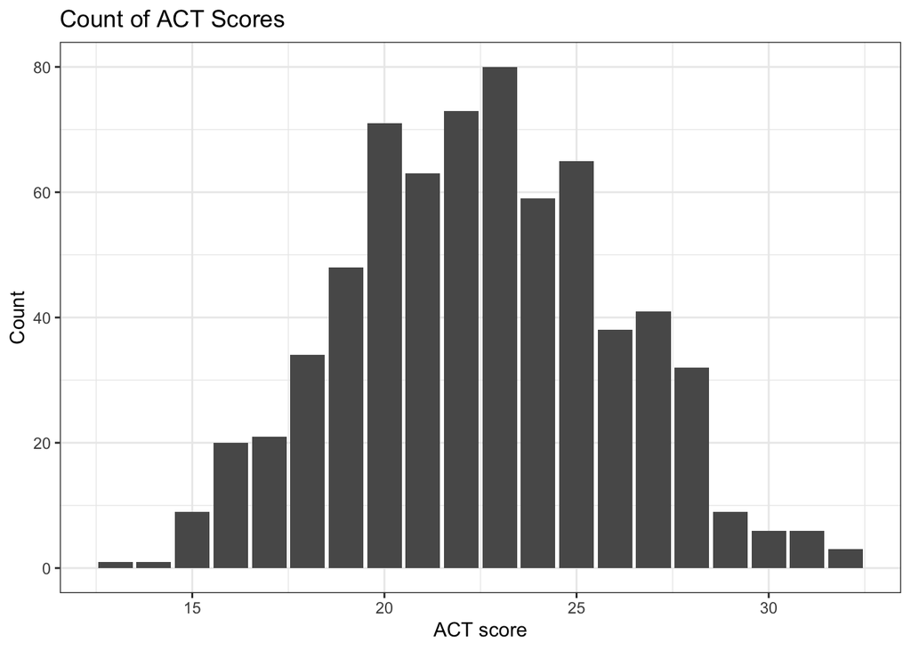

```r
library(wooldridge)
library(ggplot2)
library(dplyr)

data("attend")
df <- attend %>%
  mutate(
    soph_f = factor(soph, levels = c(0, 1),
                    labels = c("Not Sophomore (0)", "Sophomore (1)"))
  )

# 3.1 Barplot: count of ACT scores
p31 <- ggplot(df, aes(x = ACT)) +
  geom_bar() +
  theme_bw() +
  labs(
    title = "Count of ACT Scores",
    x = "ACT score",
    y = "Count"
  )
p31
```

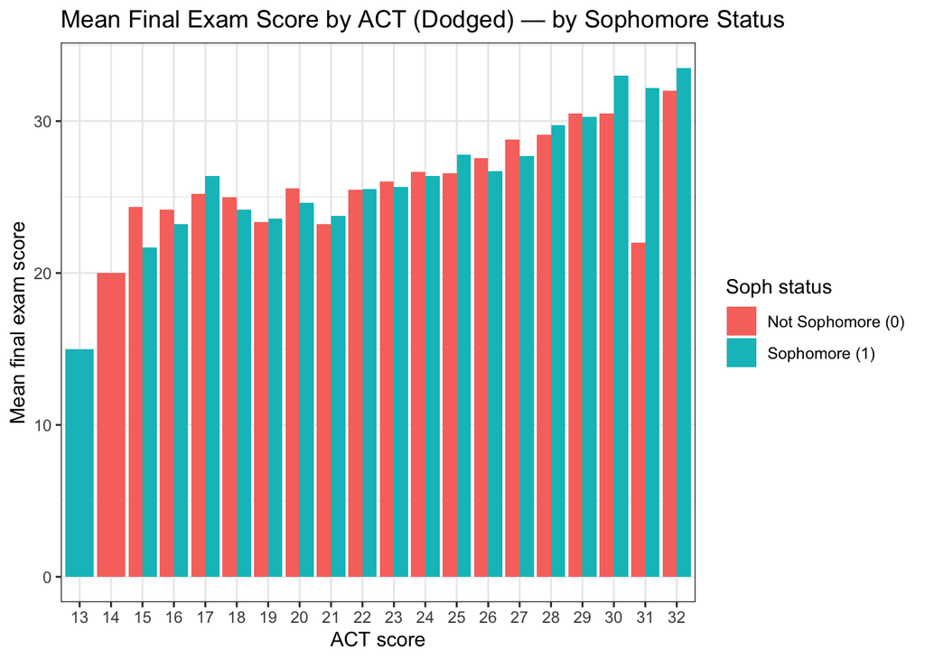

```r
# For 3.2, ACT must be treated as categorical to make a bar chart by ACT level
df2 <- df %>% mutate(ACT_f = factor(ACT))

# --- 3.2 (A) Dodged bar chart (y = mean(final) by ACT, filled by soph)
p_dodge <- ggplot(df2, aes(x = ACT_f, y = final, fill = soph_f)) +
  stat_summary(fun = mean, geom = "bar", position = "dodge") +
  theme_bw() +
  labs(
    title = "Mean Final Exam Score by ACT (Dodged) — by Sophomore Status",
    x = "ACT score",
    y = "Mean final exam score",
    fill = "Soph status"
  )
p_dodge
```

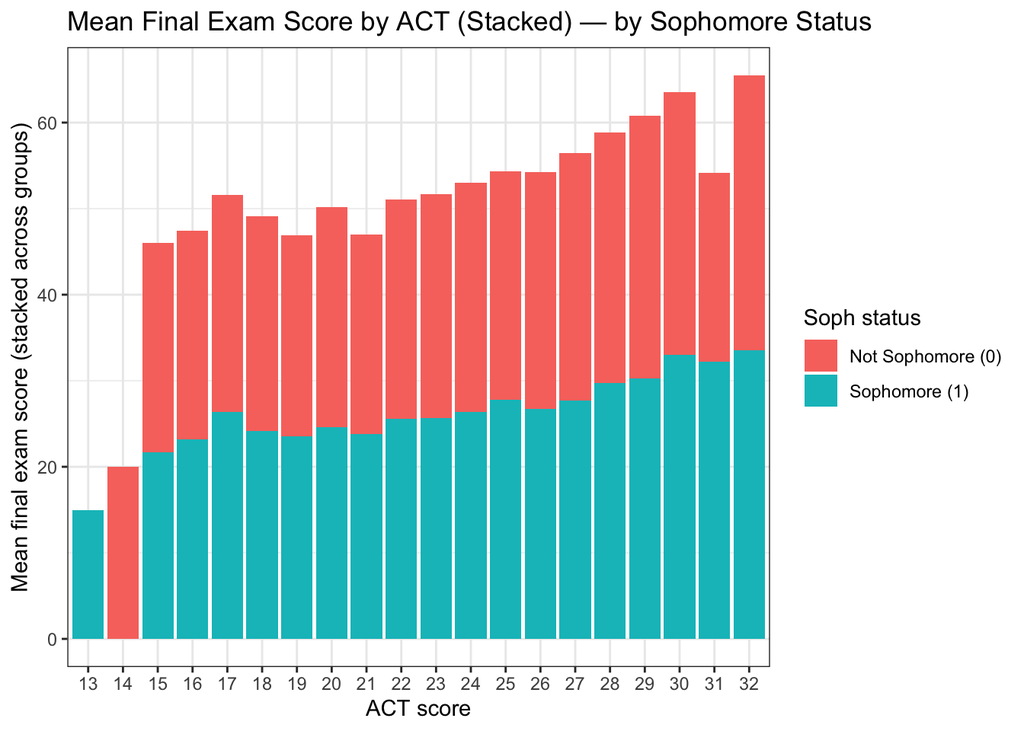

```r
# --- 3.2 (B) Stacked bar chart (same summary, stacked)
p_stack <- ggplot(df2, aes(x = ACT_f, y = final, fill = soph_f)) +
  stat_summary(fun = mean, geom = "bar", position = "stack") +
  theme_bw() +
  labs(
    title = "Mean Final Exam Score by ACT (Stacked) — by Sophomore Status",
    x = "ACT score",
    y = "Mean final exam score (stacked across groups)",
    fill = "Soph status"
  )
p_stack
```

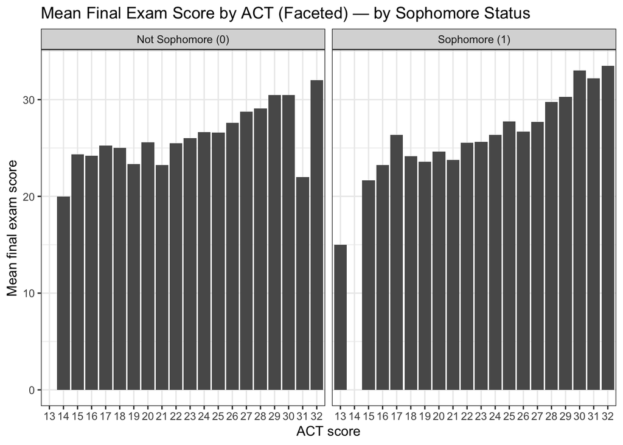

```r
# --- 3.2 (C) Faceted bar chart (mean(final) by ACT in separate panels)
p_facet <- ggplot(df2, aes(x = ACT_f, y = final)) +
  stat_summary(fun = mean, geom = "bar") +
  facet_wrap(~ soph_f) +
  theme_bw() +
  labs(
    title = "Mean Final Exam Score by ACT (Faceted) — by Sophomore Status",
    x = "ACT score",
    y = "Mean final exam score"
  )
p_facet
```

## 3.1 3.2 What distribution does ACT count resemble?

A bar plot of ACT values often looks roughly bell-shaped (approximately normal): most students cluster around a middle ACT range, with fewer observations at very low/high ACT scores. (It won’t be perfectly smooth because ACT is discrete and sample sizes vary.)

## 3.2 3.3 Which chart “accurately” describes the data, and why?

- Most accurate: Dodged or faceted
  - They let you compare mean (final) between sophomore groups with the same ACT score **without** mixing groups.
- Least appropriate: Stacked
  - Stacking can be misleading because stacking implies “parts of a whole”
  - The stack height becomes the mean of group A + the mean of groups B which is **not** a meaningful quantity for final exam scores

# 4 Ex 4: Barplots with ACT averages (Understand Bar plots)

```r
library(wooldridge)
library(dplyr)
library(ggplot2)

data("attend")

# Relabel soph (same idea as earlier)
df_soph_relabeled <- attend %>%
  mutate(
    soph_f = factor(soph, levels = c(0, 1),
                    labels = c("Not Sophomore (0)", "Sophomore (1)"))
  )

# 4.1 Summarize: average final by soph and ACT + sample size
df_soph_relabeled_summarized <- df_soph_relabeled %>%
  group_by(soph_f, ACT) %>%
  summarise(
    final_avg = mean(final, na.rm = TRUE),
    n = n(),
    .groups = "drop"
  ) %>%
  mutate(ACT_f = factor(ACT))  # treat ACT as categorical for bar charts

df_soph_relabeled_summarized
```

```
# A tibble: 38 × 5
   soph_f              ACT final_avg     n ACT_f
   <fct>             <int>     <dbl> <int> <fct>
 1 Not Sophomore (0)    14      20       1 14
 2 Not Sophomore (0)    15      24.3     6 15
 3 Not Sophomore (0)    16      24.2    11 16
 4 Not Sophomore (0)    17      25.2    13 17
 5 Not Sophomore (0)    18      25      14 18
 6 Not Sophomore (0)    19      23.3    23 19
 7 Not Sophomore (0)    20      25.6    30 20
 8 Not Sophomore (0)    21      23.2    29 21
 9 Not Sophomore (0)    22      25.5    28 22
10 Not Sophomore (0)    23      26.0    38 23
# ℹ 28 more rows
```

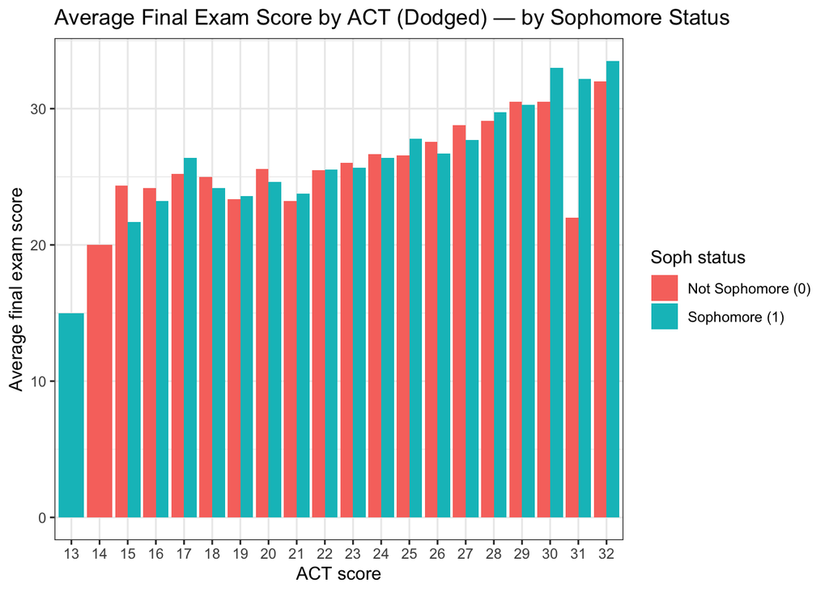

```r
# --- 4.1 (A) Dodged bar chart (y = final_avg)
p4_dodge <- ggplot(df_soph_relabeled_summarized,
                   aes(x = ACT_f, y = final_avg, fill = soph_f)) +
  geom_col(position = "dodge") +
  theme_bw() +
  labs(
    title = "Average Final Exam Score by ACT (Dodged) — by Sophomore Status",
    x = "ACT score",
    y = "Average final exam score",
    fill = "Soph status"
  )
p4_dodge
```

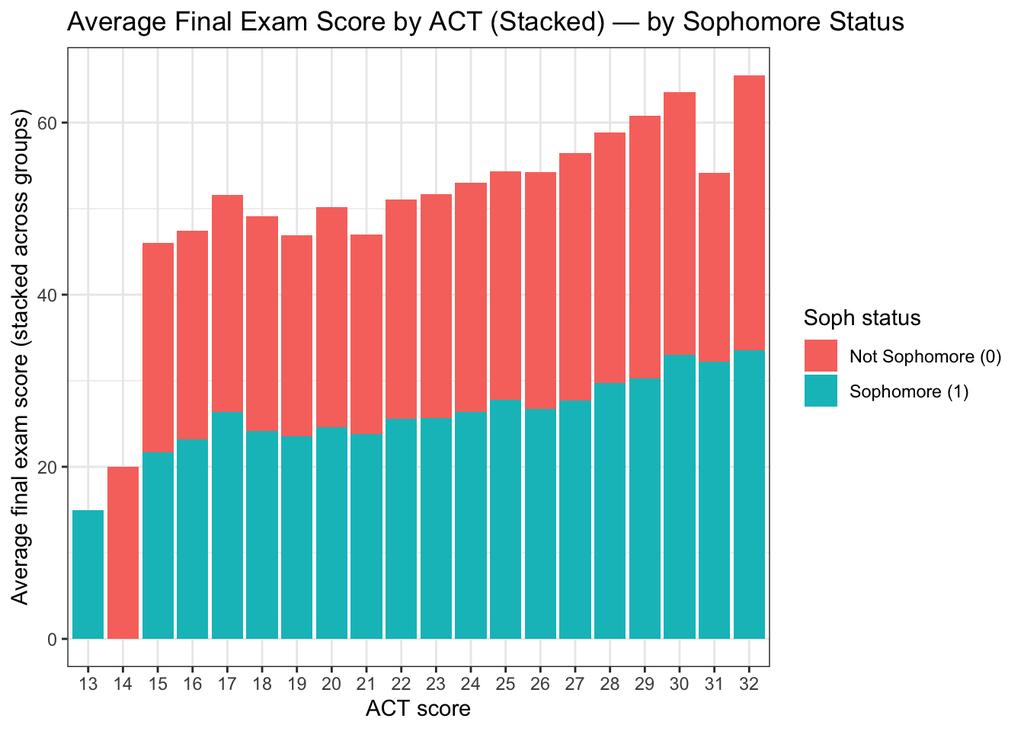

```r
# --- 4.1 (B) Stacked bar chart (y = final_avg)  [shown because prompt asks, but see notes in 4.2]
p4_stack <- ggplot(df_soph_relabeled_summarized,
                   aes(x = ACT_f, y = final_avg, fill = soph_f)) +
  geom_col(position = "stack") +
  theme_bw() +
  labs(
    title = "Average Final Exam Score by ACT (Stacked) — by Sophomore Status",
    x = "ACT score",
    y = "Average final exam score (stacked across groups)",
    fill = "Soph status"
  )
p4_stack
```

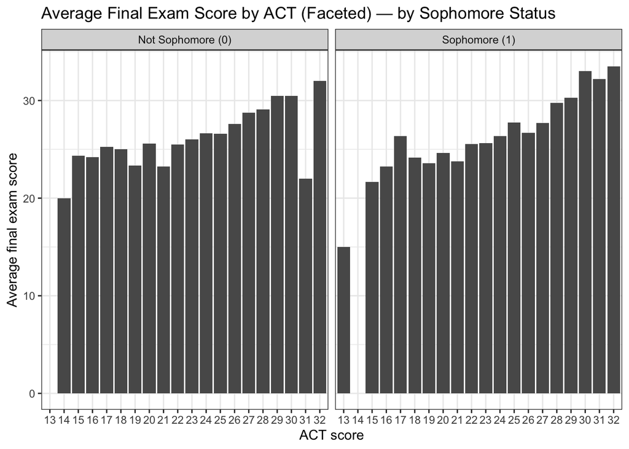

```r
# --- 4.1 (C) Faceted bar chart (y = final_avg)
p4_facet <- ggplot(df_soph_relabeled_summarized,
                   aes(x = ACT_f, y = final_avg)) +
  geom_col() +
  facet_wrap(~ soph_f) +
  theme_bw() +
  labs(
    title = "Average Final Exam Score by ACT (Faceted) — by Sophomore Status",
    x = "ACT score",
    y = "Average final exam score"
  )
p4_facet
```

## 4.1 Which charts accurately describe the data? Why?

- faceted/dodged
  - shows average final score for each **ACT** level sperately for each sophmore group which matches the meaning of final_avg
- Not accurate / misleading: **Stacked**
  - Stacking averages creates a bar height that equals **avg(non-soph) + avg(soph)**, which is **not a meaningful statistic** for exam scores (it suggests “parts of a whole,” but averages are not parts).

## 4.2 **Q3.2 dodged vs Q4 dodged: which would you trust?**

**Trust the Q4 dodged chart** (the one using final_avg after summarizing). Why: - In Q3, if you used final directly in a bar, ggplot has to **aggregate** somehow (and beginners often end up with something that *looks* like a mean but they didn’t explicitly compute it). - In Q4, you **explicitly compute the mean** by group_by(soph, ACT) then plot final_avg. That’s transparent, reproducible, and you can also inspect **n**.

## 4.3 Differences in patterns between soph and non-soph

What to look for: - If both groups’ averages rise with ACT, you’ll say: **higher ACT is associated with higher average final scores** for both groups.

# 5 Ex 5: Boxplot vs. correct barplot

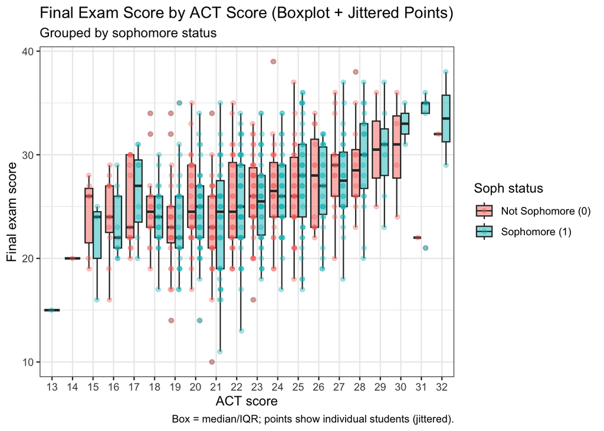

```r
library(wooldridge)
library(dplyr)
library(ggplot2)

data("attend")

df <- attend %>%
  mutate(
    soph_f = factor(soph, levels = c(0, 1),
                    labels = c("Not Sophomore (0)", "Sophomore (1)")),
    ACT_f = factor(ACT)   # treat ACT as categorical for boxplots
  )

ggplot(df, aes(x = ACT_f, y = final, fill = soph_f)) +
  geom_boxplot(alpha = 0.5, outlier.alpha = 0.3, position = position_dodge(width = 0.8)) +
  geom_jitter(
    aes(color = soph_f),
    position = position_jitterdodge(jitter.width = 0.15, dodge.width = 0.8),
    alpha = 0.35,
    size = 1.5
  ) +
  theme_bw() +
  labs(
    title = "Final Exam Score by ACT Score (Boxplot + Jittered Points)",
    subtitle = "Grouped by sophomore status",
    x = "ACT score",
    y = "Final exam score",
    fill = "Soph status",
    color = "Soph status",
    caption = "Box = median/IQR; points show individual students (jittered)."
  )
```

## 5.1 **5.2 Box plot vs. “correct” bar plot (from Q4) + which I prefer**

The **barplot (Q4)** summarizes each ACT × soph group with a **single average final score**, which is simple for comparing central tendency but hides what’s happening inside each group. Your **boxplot (Q5)** shows the **median and spread (IQR)** of final scores at each ACT score, plus the jittered points reveal **sample density and outliers**. In your figure, many ACT levels have noticeable spread (often several points wide) and a few unusually low or high scores—details that would be invisible in a mean-only bar chart.

I prefer the **boxplot + jitter** because it shows **both** the typical score (median) **and** variability/outliers, making it easier to judge whether apparent differences between groups are meaningful or just due to noisy/small-sample ACT levels. The barplot is still useful as a quick “average trend” summary, but the boxplot is more informative and less likely to oversimplify.

## 5.2 **5.3 Differences in ACT–final patterns for soph vs non-soph (what your plot suggests)**

Your plot shows a **clear positive relationship** between **ACT and final exam score** for **both** groups: as ACT increases from the mid-teens into the high 20s/low 30s, the **boxes and medians shift upward**, indicating higher typical final scores at higher ACT levels.

Comparing groups, the **Sophomore (1)** and **Not Sophomore (0)** distributions **overlap heavily** at most ACT scores, and the medians are usually **close**—so sophomore status doesn’t look like it creates a huge difference in final scores once ACT is considered. If anything, at some higher ACT values the sophomore group’s median looks **slightly higher**, but the overlap is still substantial.

Finally, variability is **non-trivial** at many ACT levels (wide boxes and scattered points), meaning that students with the same ACT can still have quite different final scores. This is another reason the boxplot is helpful: it shows that ACT predicts higher performance *on average*, but there’s still plenty of spread within each ACT group.

# 6 Ex 6: Impact of ACT on attednace, moderated by freshman status: Boxplot

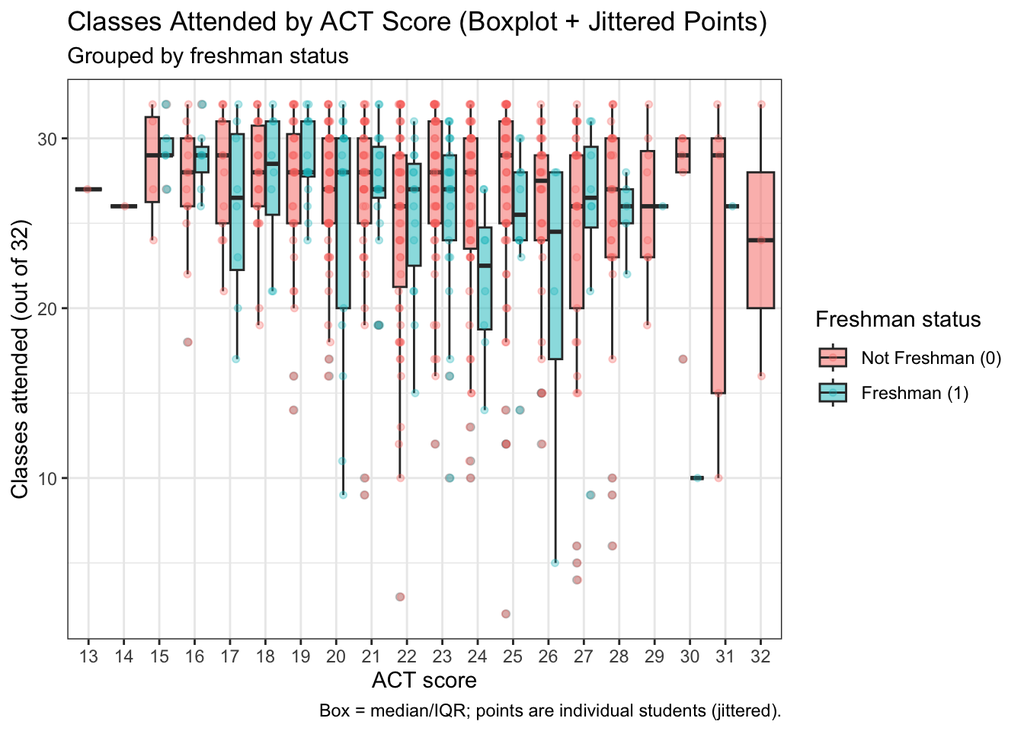

```r
library(wooldridge)
library(dplyr)
library(ggplot2)

data("attend")

df <- attend %>%
  mutate(
    ACT_f   = factor(ACT),  # make ACT discrete for boxplot x-axis
    frosh_f = factor(frosh, levels = c(0, 1),
                     labels = c("Not Freshman (0)", "Freshman (1)"))
  )

# (A) One chart: grouped boxplots (side-by-side) + jittered points
ggplot(df, aes(x = ACT_f, y = attend, fill = frosh_f)) +
  geom_boxplot(alpha = 0.5, position = position_dodge(width = 0.8),
               outlier.alpha = 0.25) +
  geom_jitter(
    aes(color = frosh_f),
    position = position_jitterdodge(jitter.width = 0.15, dodge.width = 0.8),
    alpha = 0.30, size = 1.3
  ) +
  theme_bw() +
  labs(
    title = "Classes Attended by ACT Score (Boxplot + Jittered Points)",
    subtitle = "Grouped by freshman status",
    x = "ACT score",
    y = "Classes attended (out of 32)",
    fill = "Freshman status",
    color = "Freshman status",
    caption = "Box = median/IQR; points are individual students (jittered)."
  )
```

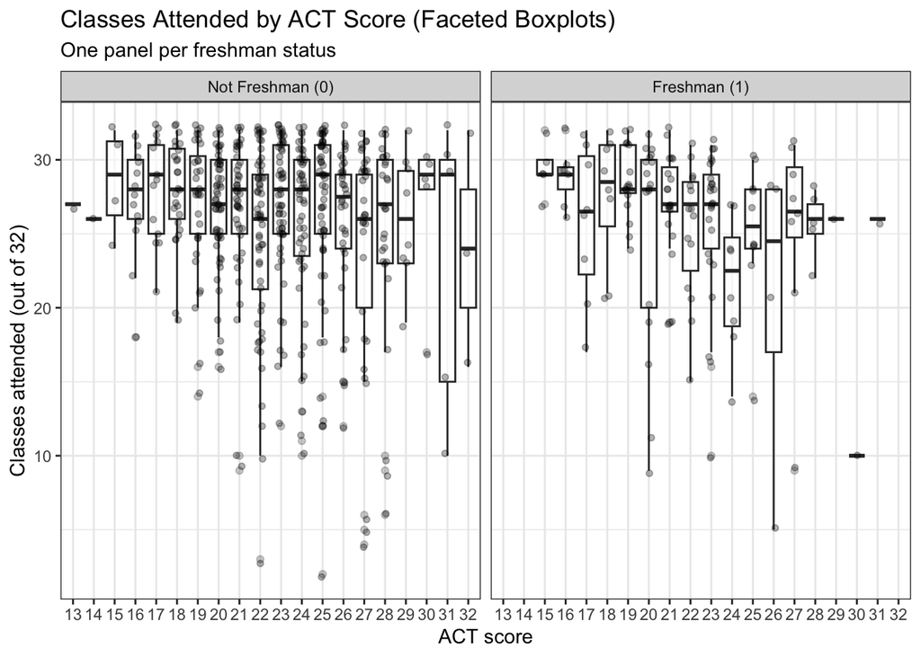

```r
# (B) Two charts: facet by freshman status (often easier to compare patterns)
ggplot(df, aes(x = ACT_f, y = attend)) +
  geom_boxplot(alpha = 0.6, outlier.alpha = 0.25) +
  geom_jitter(alpha = 0.30, width = 0.15, size = 1.3) +
  facet_wrap(~ frosh_f) +
  theme_bw() +
  labs(
    title = "Classes Attended by ACT Score (Faceted Boxplots)",
    subtitle = "One panel per freshman status",
    x = "ACT score",
    y = "Classes attended (out of 32)"
)
```

### 6.0.1 **What the plots show**

- **Not Freshman (0):** Attendance is generally **high across most ACT scores** (medians clustered around the high-20s out of 32), but there’s **more spread** at many ACT values and quite a few **low-attendance outliers** (some students missing a lot of classes) spread throughout the ACT range.
- **Freshman (1):** The medians are also **fairly high**, but the panel looks **noisier** with fewer points at some ACT scores (suggesting smaller sample sizes). There are still some **low-attendance outliers**, and the variability seems to jump more from ACT to ACT.

### 6.0.2 **6.2 Is the relationship the same for non-freshmen vs freshmen?**

**Not exactly.** In both groups, there isn’t a strong “higher ACT leads higher attendance” pattern (attendance stays relatively high across ACT levels), so ACT doesn’t look like a strong driver of attendance overall. However, the **non-freshman group shows a more stable pattern** (more consistent medians and lots of data), while the **freshman group looks more variable/noisy** and appears more affected by small-sample ACT levels. So freshman status seems to **moderate the relationship mainly by changing variability/stability**, not by flipping the direction of the relationship.

# 7 Ex 7: Attendancce by ACT, moderated by freshman status: Scatter Plot

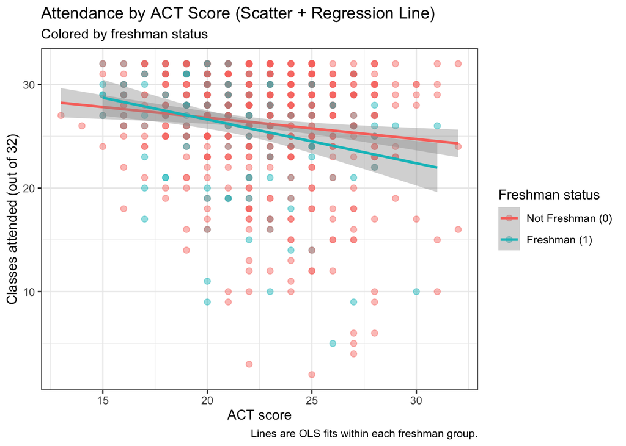

```r
library(wooldridge)
library(dplyr)
library(ggplot2)

data("attend")

df <- attend %>%
  mutate(
    frosh_f = factor(frosh, levels = c(0, 1),
                     labels = c("Not Freshman (0)", "Freshman (1)"))
  )

# (A) One chart: both groups together + separate regression lines
ggplot(df, aes(x = ACT, y = attend, color = frosh_f)) +
  geom_point(alpha = 0.45, size = 2) +
  geom_smooth(method = "lm", se = TRUE) +
  theme_bw() +
  labs(
    title = "Attendance by ACT Score (Scatter + Regression Line)",
    subtitle = "Colored by freshman status",
    x = "ACT score",
    y = "Classes attended (out of 32)",
    color = "Freshman status",
    caption = "Lines are OLS fits within each freshman group."
  )
```

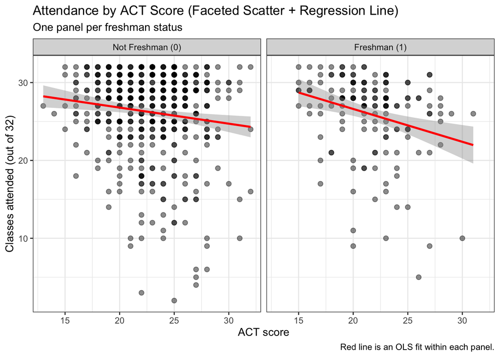

```r
# (B) Two charts: facet by freshman status (often clearer)
ggplot(df, aes(x = ACT, y = attend)) +
  geom_point(alpha = 0.45, size = 2) +
  geom_smooth(method = "lm", se = TRUE, color = "red") +
  facet_wrap(~ frosh_f) +
  theme_bw() +
  labs(
    title = "Attendance by ACT Score (Faceted Scatter + Regression Line)",
    subtitle = "One panel per freshman status",
    x = "ACT score",
    y = "Classes attended (out of 32)",
    caption = "Red line is an OLS fit within each panel."
  )
```

## 7.1 Do group differences become clear or obscure with the scatter + fitted line?

They become **clearer**. The scatterplot makes it obvious that the ACT attendance relationship is **negative** in both groups (downward red lines), and it also makes the **difference in slopes** between groups easier to see than in bar/box plots. At the same time, the scatter shows **a lot of variability** (many points clustered near high attendance with some low-attendance outliers), which explains why the relationship isn’t “tight” even though the trend is visible.

## 7.2 Summary of the relationship + how it differs by freshman status

- **Overall relationship:** In both panels, the fitted line slopes downward, suggesting that **higher ACT scores are associated with slightly lower class attendance** (fewer classes attended out of 32).
- **Moderation (difference across groups):** The downward slope is **stronger for Freshmen (1)** than for Not Freshmen (0). In other words, ACT appears to be more negatively related to attendance among freshmen.
- **Variability/outliers:** Both groups show substantial spread, including some students with **very low attendance** across a range of ACT scores. The clustering near the top (around ~28–32 attended) plus outliers suggests ACT alone doesn’t explain attendance very well, even though the negative trend exists.

# 8 Ex 8: Correlations

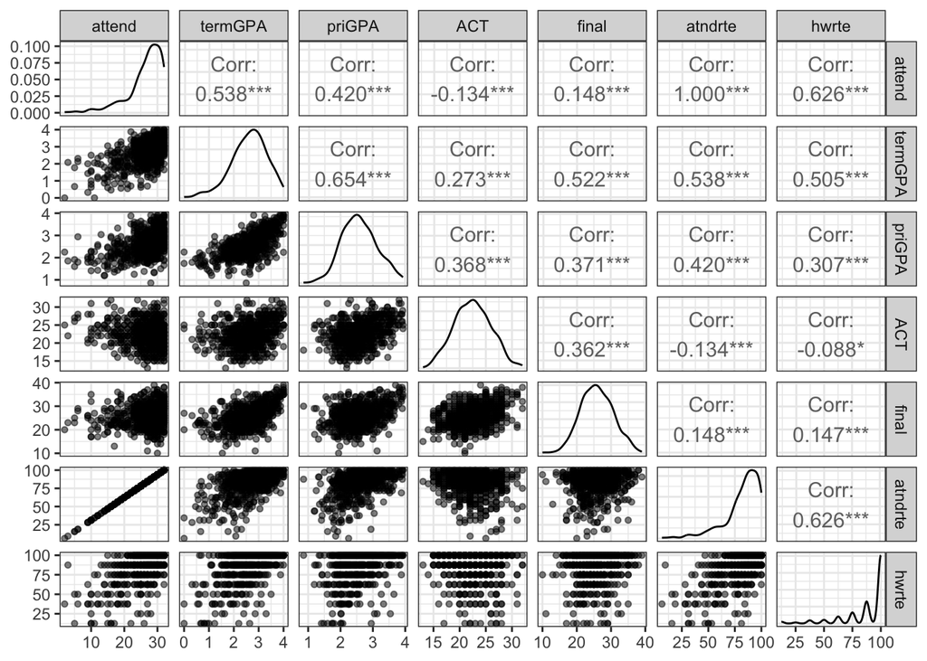

```r
library(wooldridge)
library(GGally)
library(dplyr)
library(ggplot2)

data("attend")

vars <- c("attend","termGPA","priGPA","ACT","final","atndrte","hwrte")

df_cor <- attend %>%
  select(all_of(vars)) %>%
  na.omit()

# ---- 8.1 (A) ggpairs: scatterplots + correlations
ggpairs(
  df_cor,
  upper = list(continuous = wrap("cor", size = 4)),
  lower = list(continuous = wrap("points", alpha = 0.5, size = 1.2)),
  diag  = list(continuous = "densityDiag")
) +
  theme_bw()
```

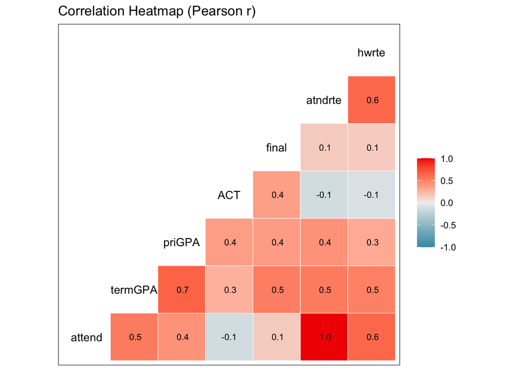

```r
# ---- 8.1 (B) ggcorr: correlation heatmap
ggcorr(
  df_cor,
  method = c("pairwise", "pearson"),
  label = TRUE,
  label_size = 3
) +
  theme_bw() +
  labs(title = "Correlation Heatmap (Pearson r)")
```

```r
# ---- 8.2 Find the highest positive correlation pair + next highest
C <- cor(df_cor, use = "pairwise.complete.obs")

# zero out diagonal + lower triangle so we only search unique pairs
C_upper <- C
C_upper[lower.tri(C_upper, diag = TRUE)] <- NA

# sort correlations high -> low
pairs_sorted <- sort(C_upper, decreasing = TRUE, na.last = NA)

# top pair
top_r <- pairs_sorted[1]
top_idx <- which(C_upper == top_r, arr.ind = TRUE)[1,]
top_pair <- c(rownames(C_upper)[top_idx[1]], colnames(C_upper)[top_idx[2]])

cat("Highest positive correlation:\n",
    top_pair[1], "and", top_pair[2], "with r =", round(top_r, 3), "\n\n")
```

```
Highest positive correlation:
 attend and atndrte with r = 1
```

```r
# next few highest (you can change 5 to however many you want)
cat("Next highest correlations:\n")
```

```
Next highest correlations:
```

```r
print(round(pairs_sorted[2:6], 3))
```

```
[1] 0.654 0.626 0.626 0.538 0.538
```

## 8.1 ggpairs() vs ggcorr(): which do I like and why

- **ggcorr()** (heatmap) is great for a **quick scan** of which relationships are strongest/weakest.
- **ggpairs()** is more informative because it shows the **scatterplots + distributions**, so you can see **outliers, ceiling effects, and nonlinearity** that a single correlation number can hide.
- **I prefer ggpairs()** here because several variables (like attendance measures) have **ceiling clustering** and visible structure in the scatterplots, and ggpairs() makes that easier to interpret.

## 8.2 Highest positive correlation + next highest

### 8.2.1 **Highest positive correlation**

- **attend and atndrte: r = 1.000**

  This makes perfect sense because atndrte is basically attend expressed as a **percentage** (same information, different scale).

### 8.2.2 **Next highest correlations (after that)**

- **termGPA and priGPA: r = 0.654**

  Makes sense: students who had higher GPA before the term tend to also earn higher GPA during the term.
- **attend and hwrte: r = 0.626**

Other fairly strong ones you have:

- **termGPA & atndrte: r = 0.538**
- **attend & termGPA: r = 0.538**
- **termGPA & final: r = 0.522**
- **termGPA & hwrte: r = 0.505**

## 8.3 **8.3 Attendance rate vs homework rate: which looks more effective for improving GPA?**

Eyeballing correlations with **GPA outcomes**:

**With term GPA**

termGPA vs **atndrte**: **r = 0.538**

- termGPA vs **hwrte**: **r = 0.505**
- **Attendance rate (atndrte)** is slightly more strongly associated with term GPA.

**With pri GPA**

- priGPA vs **atndrte**: **r = 0.420**
- priGPA vs **hwrte**: **r = 0.307**
- **attendance rate (atndrte)** shows a clearly stronger association.

**Conclusion:** Based on your correlation results, **attendance rate (atndrte) looks like the more effective lever** (stronger correlation with both termGPA and priGPA)—with the usual reminder that correlation ≠ causation.

# 9 Ex 9: Scatter plot with regression line for the Impact of priGPA on termGPA

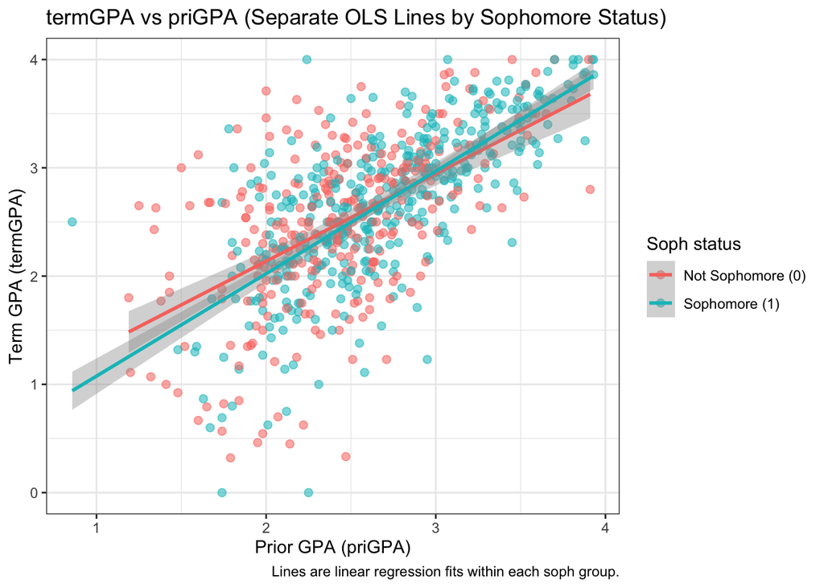

```r
library(wooldridge)
library(dplyr)
library(ggplot2)

data("attend")

df <- attend %>%
  mutate(
    soph_f = factor(soph, levels = c(0, 1),
                    labels = c("Not Sophomore (0)", "Sophomore (1)"))
  )

plot <- ggplot(df, aes(x = priGPA, y = termGPA, color = soph_f)) +
  geom_point(alpha = 0.55, size = 2) +
  geom_smooth(method = "lm", se = TRUE) +
  theme_bw() +
  labs(
    title = "termGPA vs priGPA (Separate OLS Lines by Sophomore Status)",
    x = "Prior GPA (priGPA)",
    y = "Term GPA (termGPA)",
    color = "Soph status",
    caption = "Lines are linear regression fits within each soph group."
  )

plot  # print the chart
```

## 9.1 **9.2 What can you say about the strength of priGPA–termGPA relationship?**

From your earlier correlation matrix, **termGPA and priGPA have a fairly strong positive correlation (~0.654)**, so you should expect:

- A **clear positive linear trend**: higher priGPA generally predicts higher termGPA.
- The relationship is **moderately strong** (not perfect): you’ll still see scatter around the lines because term GPA also depends on course difficulty, effort this term, attendance/homework, etc.
- When you split by soph, you’ll likely see **two very similar upward lines** unless the interaction term shows a meaningful difference—so sophomore status may shift the line slightly (level) and/or slightly change the slope (moderation).

# 10 Ex 10: Interactive Plot & Save the plot from EX 9.

```r
# install.packages("plotly")  # if needed
library(plotly)

# If your Ex9 plot used df with soph_f, make sure df still exists.
# Add hover labels (shows soph + priGPA + termGPA)
plot_labeled <- plot +
  aes(text = paste0(
    "soph: ", soph,               # or use soph_f if you prefer labels
    "<br>priGPA: ", round(priGPA, 2),
    "<br>termGPA: ", round(termGPA, 2)
  ))

plot_labeled <- plot + aes(text = paste0("soph: ", soph_f,
                                        "<br>priGPA: ", round(priGPA,2),
                                        "<br>termGPA: ", round(termGPA,2)))
ggplotly(plot_labeled, tooltip = "text")
```

[interactive chart not shown]

```r
ggsave("myplot.png", plot = plot, width = 8, height = 5, dpi = 300)
```

## 10.1 Github Education Application

[figure not shown]